# Risk Factor Analysis

## Outcome Variable

**Outcome Variable:** wasted

## Predictor Variables

**Intervention Variable:** impfloor

**Adjustment Set:**

- arm
- sex
- W_mage
- meducyrs
- feducyrs
- hhwealth_quart
- hfoodsec
- W_mhtcm
- W_nrooms
- W_nchldlt5
- W_parity
- impsan
- safeh20
- delta_W_mage
- delta_meducyrs
- delta_feducyrs
- delta_hhwealth_quart
- delta_hfoodsec
- delta_W_mhtcm
- delta_W_nrooms
- delta_W_nchldlt5
- delta_W_parity
- delta_impsan
- delta_safeh20

## Stratifying Variables

The analysis was stratified on these variable(s):

- agecat
- studyid
- country

## Data Summary

| agecat | studyid | country | impfloor | wasted | n_cell | n |
| --- | --- | --- | --- | --- | --- | --- |
| Birth | ki0047075b-MAL-ED | BANGLADESH | 0 | 0 | 17 | 222 |
| Birth | ki0047075b-MAL-ED | BANGLADESH | 0 | 1 | 0 | 222 |
| Birth | ki0047075b-MAL-ED | BANGLADESH | 1 | 0 | 167 | 222 |
| Birth | ki0047075b-MAL-ED | BANGLADESH | 1 | 1 | 38 | 222 |
| Birth | ki0047075b-MAL-ED | BRAZIL | 0 | 0 | 2 | 167 |
| Birth | ki0047075b-MAL-ED | BRAZIL | 0 | 1 | 0 | 167 |
| Birth | ki0047075b-MAL-ED | BRAZIL | 1 | 0 | 159 | 167 |
| Birth | ki0047075b-MAL-ED | BRAZIL | 1 | 1 | 6 | 167 |
| Birth | ki0047075b-MAL-ED | INDIA | 0 | 0 | 8 | 188 |
| Birth | ki0047075b-MAL-ED | INDIA | 0 | 1 | 2 | 188 |
| Birth | ki0047075b-MAL-ED | INDIA | 1 | 0 | 150 | 188 |
| Birth | ki0047075b-MAL-ED | INDIA | 1 | 1 | 28 | 188 |
| Birth | ki0047075b-MAL-ED | NEPAL | 0 | 0 | 87 | 159 |
| Birth | ki0047075b-MAL-ED | NEPAL | 0 | 1 | 8 | 159 |
| Birth | ki0047075b-MAL-ED | NEPAL | 1 | 0 | 52 | 159 |
| Birth | ki0047075b-MAL-ED | NEPAL | 1 | 1 | 12 | 159 |
| Birth | ki0047075b-MAL-ED | PERU | 0 | 0 | 194 | 252 |
| Birth | ki0047075b-MAL-ED | PERU | 0 | 1 | 4 | 252 |
| Birth | ki0047075b-MAL-ED | PERU | 1 | 0 | 53 | 252 |
| Birth | ki0047075b-MAL-ED | PERU | 1 | 1 | 1 | 252 |
| Birth | ki0047075b-MAL-ED | SOUTH AFRICA | 0 | 0 | 20 | 216 |
| Birth | ki0047075b-MAL-ED | SOUTH AFRICA | 0 | 1 | 0 | 216 |
| Birth | ki0047075b-MAL-ED | SOUTH AFRICA | 1 | 0 | 182 | 216 |
| Birth | ki0047075b-MAL-ED | SOUTH AFRICA | 1 | 1 | 14 | 216 |
| Birth | ki0047075b-MAL-ED | TANZANIA, UNITED REPUBLIC OF | 0 | 0 | 104 | 113 |
| Birth | ki0047075b-MAL-ED | TANZANIA, UNITED REPUBLIC OF | 0 | 1 | 2 | 113 |
| Birth | ki0047075b-MAL-ED | TANZANIA, UNITED REPUBLIC OF | 1 | 0 | 7 | 113 |
| Birth | ki0047075b-MAL-ED | TANZANIA, UNITED REPUBLIC OF | 1 | 1 | 0 | 113 |
| Birth | ki1000108-CMC-V-BCS-2002 | INDIA | 0 | 0 | 0 | 71 |
| Birth | ki1000108-CMC-V-BCS-2002 | INDIA | 0 | 1 | 0 | 71 |

[output cut: 154 more lines]

The following strata were considered:

- agecat: 24 months, studyid: ki0047075b-MAL-ED, country: BANGLADESH
- agecat: 24 months, studyid: ki0047075b-MAL-ED, country: BRAZIL
- agecat: 24 months, studyid: ki0047075b-MAL-ED, country: INDIA
- agecat: 24 months, studyid: ki0047075b-MAL-ED, country: NEPAL
- agecat: 24 months, studyid: ki0047075b-MAL-ED, country: PERU
- agecat: 24 months, studyid: ki0047075b-MAL-ED, country: SOUTH AFRICA
- agecat: 24 months, studyid: ki0047075b-MAL-ED, country: TANZANIA, UNITED REPUBLIC OF
- agecat: 24 months, studyid: ki1000108-CMC-V-BCS-2002, country: INDIA
- agecat: 24 months, studyid: ki1000108-IRC, country: INDIA
- agecat: 24 months, studyid: ki1017093-NIH-Birth, country: BANGLADESH
- agecat: 24 months, studyid: ki1017093b-PROVIDE, country: BANGLADESH
- agecat: 24 months, studyid: ki1017093c-NIH-Crypto, country: BANGLADESH
- agecat: 24 months, studyid: ki1113344-GMS-Nepal, country: NEPAL
- agecat: 24 months, studyid: ki1114097-CONTENT, country: PERU
- agecat: 24 months, studyid: kiGH5241-JiVitA-3, country: BANGLADESH
- agecat: 24 months, studyid: kiGH5241-JiVitA-4, country: BANGLADESH
- agecat: 6 months, studyid: ki0047075b-MAL-ED, country: BANGLADESH
- agecat: 6 months, studyid: ki0047075b-MAL-ED, country: BRAZIL
- agecat: 6 months, studyid: ki0047075b-MAL-ED, country: INDIA
- agecat: 6 months, studyid: ki0047075b-MAL-ED, country: NEPAL
- agecat: 6 months, studyid: ki0047075b-MAL-ED, country: PERU
- agecat: 6 months, studyid: ki0047075b-MAL-ED, country: SOUTH AFRICA
- agecat: 6 months, studyid: ki0047075b-MAL-ED, country: TANZANIA, UNITED REPUBLIC OF
- agecat: 6 months, studyid: ki1000108-CMC-V-BCS-2002, country: INDIA
- agecat: 6 months, studyid: ki1000108-IRC, country: INDIA
- agecat: 6 months, studyid: ki1017093-NIH-Birth, country: BANGLADESH
- agecat: 6 months, studyid: ki1017093b-PROVIDE, country: BANGLADESH
- agecat: 6 months, studyid: ki1017093c-NIH-Crypto, country: BANGLADESH
- agecat: 6 months, studyid: ki1113344-GMS-Nepal, country: NEPAL
- agecat: 6 months, studyid: ki1114097-CONTENT, country: PERU
- agecat: 6 months, studyid: kiGH5241-JiVitA-3, country: BANGLADESH
- agecat: 6 months, studyid: kiGH5241-JiVitA-4, country: BANGLADESH
- agecat: Birth, studyid: ki0047075b-MAL-ED, country: BANGLADESH
- agecat: Birth, studyid: ki0047075b-MAL-ED, country: BRAZIL
- agecat: Birth, studyid: ki0047075b-MAL-ED, country: INDIA
- agecat: Birth, studyid: ki0047075b-MAL-ED, country: NEPAL
- agecat: Birth, studyid: ki0047075b-MAL-ED, country: PERU
- agecat: Birth, studyid: ki0047075b-MAL-ED, country: SOUTH AFRICA
- agecat: Birth, studyid: ki0047075b-MAL-ED, country: TANZANIA, UNITED REPUBLIC OF
- agecat: Birth, studyid: ki1000108-CMC-V-BCS-2002, country: INDIA
- agecat: Birth, studyid: ki1000108-IRC, country: INDIA
- agecat: Birth, studyid: ki1017093-NIH-Birth, country: BANGLADESH
- agecat: Birth, studyid: ki1017093c-NIH-Crypto, country: BANGLADESH
- agecat: Birth, studyid: ki1114097-CONTENT, country: PERU
- agecat: Birth, studyid: kiGH5241-JiVitA-3, country: BANGLADESH
- agecat: Birth, studyid: kiGH5241-JiVitA-4, country: BANGLADESH

### Dropped Strata

Some strata were dropped due to rare outcomes:

- agecat: Birth, studyid: ki0047075b-MAL-ED, country: BANGLADESH
- agecat: Birth, studyid: ki0047075b-MAL-ED, country: BRAZIL
- agecat: Birth, studyid: ki0047075b-MAL-ED, country: INDIA
- agecat: Birth, studyid: ki0047075b-MAL-ED, country: PERU
- agecat: Birth, studyid: ki0047075b-MAL-ED, country: SOUTH AFRICA
- agecat: Birth, studyid: ki0047075b-MAL-ED, country: TANZANIA, UNITED REPUBLIC OF
- agecat: Birth, studyid: ki1000108-CMC-V-BCS-2002, country: INDIA
- agecat: Birth, studyid: ki1000108-IRC, country: INDIA
- agecat: Birth, studyid: ki1017093-NIH-Birth, country: BANGLADESH
- agecat: Birth, studyid: ki1017093c-NIH-Crypto, country: BANGLADESH
- agecat: Birth, studyid: ki1114097-CONTENT, country: PERU
- agecat: 6 months, studyid: ki0047075b-MAL-ED, country: BANGLADESH
- agecat: 6 months, studyid: ki0047075b-MAL-ED, country: BRAZIL
- agecat: 6 months, studyid: ki0047075b-MAL-ED, country: INDIA
- agecat: 6 months, studyid: ki0047075b-MAL-ED, country: NEPAL
- agecat: 6 months, studyid: ki0047075b-MAL-ED, country: PERU
- agecat: 6 months, studyid: ki0047075b-MAL-ED, country: SOUTH AFRICA
- agecat: 6 months, studyid: ki0047075b-MAL-ED, country: TANZANIA, UNITED REPUBLIC OF
- agecat: 6 months, studyid: ki1000108-CMC-V-BCS-2002, country: INDIA
- agecat: 6 months, studyid: ki1000108-IRC, country: INDIA
- agecat: 6 months, studyid: ki1017093b-PROVIDE, country: BANGLADESH
- agecat: 6 months, studyid: ki1114097-CONTENT, country: PERU
- agecat: 24 months, studyid: ki0047075b-MAL-ED, country: BANGLADESH
- agecat: 24 months, studyid: ki0047075b-MAL-ED, country: BRAZIL
- agecat: 24 months, studyid: ki0047075b-MAL-ED, country: INDIA
- agecat: 24 months, studyid: ki0047075b-MAL-ED, country: NEPAL
- agecat: 24 months, studyid: ki0047075b-MAL-ED, country: PERU
- agecat: 24 months, studyid: ki0047075b-MAL-ED, country: SOUTH AFRICA
- agecat: 24 months, studyid: ki0047075b-MAL-ED, country: TANZANIA, UNITED REPUBLIC OF
- agecat: 24 months, studyid: ki1000108-CMC-V-BCS-2002, country: INDIA
- agecat: 24 months, studyid: ki1000108-IRC, country: INDIA
- agecat: 24 months, studyid: ki1114097-CONTENT, country: PERU

## Methods Detail

We’re interested in the causal parameters $E[Y_a]$ for all values of $a \in \mathcal{A}$. These parameters represent the mean outcome if, possibly contrary to fact, we intervened to set all units to have $A=a$. Under the randomization and positivity assumptions, these are identified by the statistical parameters $\psi_a=E_W[E_{Y|A,W}(Y|A=a,W)]$. In addition, we’re interested in the mean of $Y$, $E[Y]$ under no intervention (the observed mean). We will estimate these parameters by using SuperLearner to fit the relevant likelihood factors – $E_{Y|A,W}(Y|A=a,W)$ and $p(A=a|W)$, and then updating our likelihood fit using a joint TMLE.

For unadjusted analyses ($W=\{\}$), initial likelihoods were estimated using Lrnr_glm to estimate the simple $E(Y|A)$ and Lrnr_mean to estimate $p(A)$. For adjusted analyses, a small library containing Lrnr_glmnet, Lrnr_xgboost, and Lrnr_mean was used.

Having estimated these parameters, we will then use the delta method to estimate relative risks and attributable risks relative to a prespecified baseline level of $A$.

# Results Detail

## Results Plots

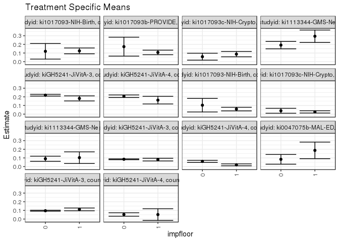

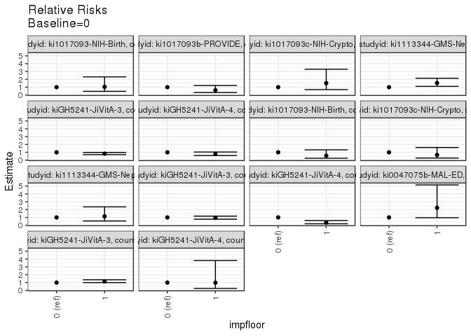

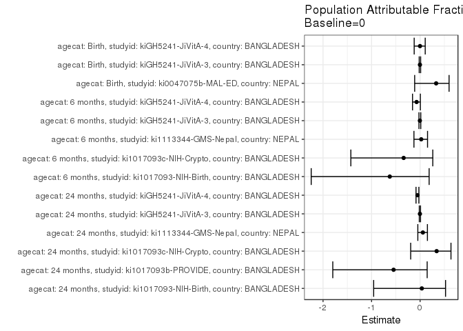

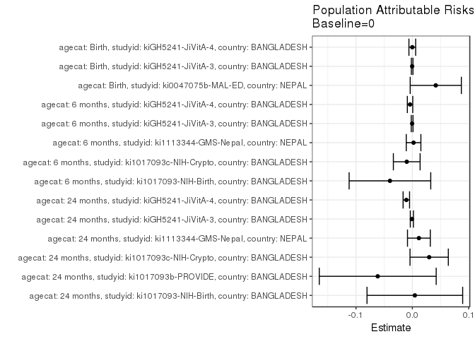

## Results Table

### Parameter: TSM

| agecat | studyid | country | intervention_level | baseline_level | estimate | ci_lower | ci_upper |
| --- | --- | --- | --- | --- | --- | --- | --- |
| Birth | ki0047075b-MAL-ED | NEPAL | 0 | NA | 0.0842105 | 0.0281913 | 0.1402298 |
| Birth | ki0047075b-MAL-ED | NEPAL | 1 | NA | 0.1875000 | 0.0915731 | 0.2834269 |
| Birth | kiGH5241-JiVitA-3 | BANGLADESH | 0 | NA | 0.0962185 | 0.0909383 | 0.1014987 |
| Birth | kiGH5241-JiVitA-3 | BANGLADESH | 1 | NA | 0.1116890 | 0.0956020 | 0.1277759 |
| Birth | kiGH5241-JiVitA-4 | BANGLADESH | 0 | NA | 0.0528000 | 0.0329385 | 0.0726615 |
| Birth | kiGH5241-JiVitA-4 | BANGLADESH | 1 | NA | 0.0517241 | -0.0157706 | 0.1192189 |
| 6 months | ki1017093-NIH-Birth | BANGLADESH | 0 | NA | 0.1034483 | 0.0249987 | 0.1818978 |
| 6 months | ki1017093-NIH-Birth | BANGLADESH | 1 | NA | 0.0588235 | 0.0376661 | 0.0799809 |
| 6 months | ki1017093c-NIH-Crypto | BANGLADESH | 0 | NA | 0.0393258 | 0.0107520 | 0.0678997 |
| 6 months | ki1017093c-NIH-Crypto | BANGLADESH | 1 | NA | 0.0260708 | 0.0125841 | 0.0395575 |
| 6 months | ki1113344-GMS-Nepal | NEPAL | 0 | NA | 0.0908131 | 0.0612234 | 0.1204028 |
| 6 months | ki1113344-GMS-Nepal | NEPAL | 1 | NA | 0.1030638 | 0.0358202 | 0.1703073 |
| 6 months | kiGH5241-JiVitA-3 | BANGLADESH | 0 | NA | 0.0848626 | 0.0799333 | 0.0897918 |
| 6 months | kiGH5241-JiVitA-3 | BANGLADESH | 1 | NA | 0.0807966 | 0.0649440 | 0.0966492 |
| 6 months | kiGH5241-JiVitA-4 | BANGLADESH | 0 | NA | 0.0604117 | 0.0484786 | 0.0723447 |
| 6 months | kiGH5241-JiVitA-4 | BANGLADESH | 1 | NA | 0.0204641 | 0.0094978 | 0.0314304 |
| 24 months | ki1017093-NIH-Birth | BANGLADESH | 0 | NA | 0.1200000 | 0.0298210 | 0.2101790 |
| 24 months | ki1017093-NIH-Birth | BANGLADESH | 1 | NA | 0.1250000 | 0.0915325 | 0.1584675 |
| 24 months | ki1017093b-PROVIDE | BANGLADESH | 0 | NA | 0.1739130 | 0.0642844 | 0.2835417 |
| 24 months | ki1017093b-PROVIDE | BANGLADESH | 1 | NA | 0.1071429 | 0.0808377 | 0.1334480 |
| 24 months | ki1017093c-NIH-Crypto | BANGLADESH | 0 | NA | 0.0577002 | 0.0176143 | 0.0977862 |
| 24 months | ki1017093c-NIH-Crypto | BANGLADESH | 1 | NA | 0.0871487 | 0.0566422 | 0.1176552 |
| 24 months | ki1113344-GMS-Nepal | NEPAL | 0 | NA | 0.1915123 | 0.1489459 | 0.2340786 |
| 24 months | ki1113344-GMS-Nepal | NEPAL | 1 | NA | 0.2941637 | 0.2223918 | 0.3659355 |
| 24 months | kiGH5241-JiVitA-3 | BANGLADESH | 0 | NA | 0.2190510 | 0.2090729 | 0.2290292 |
| 24 months | kiGH5241-JiVitA-3 | BANGLADESH | 1 | NA | 0.1817691 | 0.1524595 | 0.2110787 |
| 24 months | kiGH5241-JiVitA-4 | BANGLADESH | 0 | NA | 0.2070776 | 0.1924033 | 0.2217519 |
| 24 months | kiGH5241-JiVitA-4 | BANGLADESH | 1 | NA | 0.1618480 | 0.1174601 | 0.2062359 |

### Parameter: E(Y)

| agecat | studyid | country | intervention_level | baseline_level | estimate | ci_lower | ci_upper |
| --- | --- | --- | --- | --- | --- | --- | --- |
| Birth | ki0047075b-MAL-ED | NEPAL | NA | NA | 0.1257862 | 0.0740797 | 0.1774926 |
| Birth | kiGH5241-JiVitA-3 | BANGLADESH | NA | NA | 0.0958764 | 0.0906733 | 0.1010796 |
| Birth | kiGH5241-JiVitA-4 | BANGLADESH | NA | NA | 0.0527086 | 0.0336587 | 0.0717585 |
| 6 months | ki1017093-NIH-Birth | BANGLADESH | NA | NA | 0.0636704 | 0.0429419 | 0.0843989 |
| 6 months | ki1017093c-NIH-Crypto | BANGLADESH | NA | NA | 0.0293706 | 0.0169860 | 0.0417552 |
| 6 months | ki1113344-GMS-Nepal | NEPAL | NA | NA | 0.0929705 | 0.0658371 | 0.1201040 |
| 6 months | kiGH5241-JiVitA-3 | BANGLADESH | NA | NA | 0.0844620 | 0.0796573 | 0.0892667 |
| 6 months | kiGH5241-JiVitA-4 | BANGLADESH | NA | NA | 0.0563321 | 0.0473894 | 0.0652748 |
| 24 months | ki1017093-NIH-Birth | BANGLADESH | NA | NA | 0.1244131 | 0.0930343 | 0.1557919 |
| 24 months | ki1017093b-PROVIDE | BANGLADESH | NA | NA | 0.1124567 | 0.0866788 | 0.1382347 |
| 24 months | ki1017093c-NIH-Crypto | BANGLADESH | NA | NA | 0.0875486 | 0.0630907 | 0.1120065 |
| 24 months | ki1113344-GMS-Nepal | NEPAL | NA | NA | 0.2031250 | 0.1628324 | 0.2434176 |
| 24 months | kiGH5241-JiVitA-3 | BANGLADESH | NA | NA | 0.2181988 | 0.2083092 | 0.2280884 |
| 24 months | kiGH5241-JiVitA-4 | BANGLADESH | NA | NA | 0.1964054 | 0.1829535 | 0.2098572 |

### Parameter: RR

| agecat | studyid | country | intervention_level | baseline_level | estimate | ci_lower | ci_upper |
| --- | --- | --- | --- | --- | --- | --- | --- |
| Birth | ki0047075b-MAL-ED | NEPAL | 0 | 0 | 1.0000000 | 1.0000000 | 1.0000000 |
| Birth | ki0047075b-MAL-ED | NEPAL | 1 | 0 | 2.2265625 | 0.9619897 | 5.1534651 |
| Birth | kiGH5241-JiVitA-3 | BANGLADESH | 0 | 0 | 1.0000000 | 1.0000000 | 1.0000000 |
| Birth | kiGH5241-JiVitA-3 | BANGLADESH | 1 | 0 | 1.1607848 | 0.9955843 | 1.3533974 |
| Birth | kiGH5241-JiVitA-4 | BANGLADESH | 0 | 0 | 1.0000000 | 1.0000000 | 1.0000000 |
| Birth | kiGH5241-JiVitA-4 | BANGLADESH | 1 | 0 | 0.9796238 | 0.2517913 | 3.8113428 |
| 6 months | ki1017093-NIH-Birth | BANGLADESH | 0 | 0 | 1.0000000 | 1.0000000 | 1.0000000 |
| 6 months | ki1017093-NIH-Birth | BANGLADESH | 1 | 0 | 0.5686275 | 0.2456499 | 1.3162521 |
| 6 months | ki1017093c-NIH-Crypto | BANGLADESH | 0 | 0 | 1.0000000 | 1.0000000 | 1.0000000 |
| 6 months | ki1017093c-NIH-Crypto | BANGLADESH | 1 | 0 | 0.6629423 | 0.2717148 | 1.6174768 |
| 6 months | ki1113344-GMS-Nepal | NEPAL | 0 | 0 | 1.0000000 | 1.0000000 | 1.0000000 |
| 6 months | ki1113344-GMS-Nepal | NEPAL | 1 | 0 | 1.1348999 | 0.5476948 | 2.3516708 |
| 6 months | kiGH5241-JiVitA-3 | BANGLADESH | 0 | 0 | 1.0000000 | 1.0000000 | 1.0000000 |
| 6 months | kiGH5241-JiVitA-3 | BANGLADESH | 1 | 0 | 0.9520877 | 0.7754305 | 1.1689905 |
| 6 months | kiGH5241-JiVitA-4 | BANGLADESH | 0 | 0 | 1.0000000 | 1.0000000 | 1.0000000 |
| 6 months | kiGH5241-JiVitA-4 | BANGLADESH | 1 | 0 | 0.3387443 | 0.1920015 | 0.5976394 |
| 24 months | ki1017093-NIH-Birth | BANGLADESH | 0 | 0 | 1.0000000 | 1.0000000 | 1.0000000 |
| 24 months | ki1017093-NIH-Birth | BANGLADESH | 1 | 0 | 1.0416667 | 0.4690996 | 2.3130896 |
| 24 months | ki1017093b-PROVIDE | BANGLADESH | 0 | 0 | 1.0000000 | 1.0000000 | 1.0000000 |
| 24 months | ki1017093b-PROVIDE | BANGLADESH | 1 | 0 | 0.6160714 | 0.3132100 | 1.2117876 |
| 24 months | ki1017093c-NIH-Crypto | BANGLADESH | 0 | 0 | 1.0000000 | 1.0000000 | 1.0000000 |
| 24 months | ki1017093c-NIH-Crypto | BANGLADESH | 1 | 0 | 1.5103703 | 0.6931288 | 3.2911896 |
| 24 months | ki1113344-GMS-Nepal | NEPAL | 0 | 0 | 1.0000000 | 1.0000000 | 1.0000000 |
| 24 months | ki1113344-GMS-Nepal | NEPAL | 1 | 0 | 1.5360043 | 1.1046038 | 2.1358871 |
| 24 months | kiGH5241-JiVitA-3 | BANGLADESH | 0 | 0 | 1.0000000 | 1.0000000 | 1.0000000 |
| 24 months | kiGH5241-JiVitA-3 | BANGLADESH | 1 | 0 | 0.8298024 | 0.7030273 | 0.9794385 |
| 24 months | kiGH5241-JiVitA-4 | BANGLADESH | 0 | 0 | 1.0000000 | 1.0000000 | 1.0000000 |
| 24 months | kiGH5241-JiVitA-4 | BANGLADESH | 1 | 0 | 0.7815811 | 0.5895159 | 1.0362214 |

### Parameter: PAR

| agecat | studyid | country | intervention_level | baseline_level | estimate | ci_lower | ci_upper |
| --- | --- | --- | --- | --- | --- | --- | --- |
| Birth | ki0047075b-MAL-ED | NEPAL | 0 | NA | 0.0415756 | -0.0038305 | 0.0869818 |
| Birth | kiGH5241-JiVitA-3 | BANGLADESH | 0 | NA | -0.0003421 | -0.0017648 | 0.0010806 |
| Birth | kiGH5241-JiVitA-4 | BANGLADESH | 0 | NA | -0.0000914 | -0.0060688 | 0.0058861 |
| 6 months | ki1017093-NIH-Birth | BANGLADESH | 0 | NA | -0.0397779 | -0.1122148 | 0.0326590 |
| 6 months | ki1017093c-NIH-Crypto | BANGLADESH | 0 | NA | -0.0099552 | -0.0336897 | 0.0137792 |
| 6 months | ki1113344-GMS-Nepal | NEPAL | 0 | NA | 0.0021574 | -0.0108345 | 0.0151494 |
| 6 months | kiGH5241-JiVitA-3 | BANGLADESH | 0 | NA | -0.0004006 | -0.0019774 | 0.0011763 |
| 6 months | kiGH5241-JiVitA-4 | BANGLADESH | 0 | NA | -0.0040796 | -0.0088768 | 0.0007176 |
| 24 months | ki1017093-NIH-Birth | BANGLADESH | 0 | NA | 0.0044131 | -0.0804862 | 0.0893125 |
| 24 months | ki1017093b-PROVIDE | BANGLADESH | 0 | NA | -0.0614563 | -0.1652348 | 0.0423222 |
| 24 months | ki1017093c-NIH-Crypto | BANGLADESH | 0 | NA | 0.0298484 | -0.0041580 | 0.0638549 |
| 24 months | ki1113344-GMS-Nepal | NEPAL | 0 | NA | 0.0116127 | -0.0086151 | 0.0318406 |
| 24 months | kiGH5241-JiVitA-3 | BANGLADESH | 0 | NA | -0.0008522 | -0.0036271 | 0.0019227 |
| 24 months | kiGH5241-JiVitA-4 | BANGLADESH | 0 | NA | -0.0106723 | -0.0164011 | -0.0049434 |

### Parameter: PAF

| agecat | studyid | country | intervention_level | baseline_level | estimate | ci_lower | ci_upper |
| --- | --- | --- | --- | --- | --- | --- | --- |
| Birth | ki0047075b-MAL-ED | NEPAL | 0 | NA | 0.3305263 | -0.1120029 | 0.5969480 |
| Birth | kiGH5241-JiVitA-3 | BANGLADESH | 0 | NA | -0.0035678 | -0.0185342 | 0.0111787 |
| Birth | kiGH5241-JiVitA-4 | BANGLADESH | 0 | NA | -0.0017333 | -0.1218228 | 0.1055008 |
| 6 months | ki1017093-NIH-Birth | BANGLADESH | 0 | NA | -0.6247464 | -2.2439861 | 0.1862477 |
| 6 months | ki1017093c-NIH-Crypto | BANGLADESH | 0 | NA | -0.3389513 | -1.4270636 | 0.2613335 |
| 6 months | ki1113344-GMS-Nepal | NEPAL | 0 | NA | 0.0232054 | -0.1268902 | 0.1533091 |
| 6 months | kiGH5241-JiVitA-3 | BANGLADESH | 0 | NA | -0.0047426 | -0.0236113 | 0.0137783 |
| 6 months | kiGH5241-JiVitA-4 | BANGLADESH | 0 | NA | -0.0724205 | -0.1560495 | 0.0051587 |
| 24 months | ki1017093-NIH-Birth | BANGLADESH | 0 | NA | 0.0354717 | -0.9568468 | 0.5245847 |
| 24 months | ki1017093b-PROVIDE | BANGLADESH | 0 | NA | -0.5464883 | -1.7992750 | 0.1456266 |
| 24 months | ki1017093c-NIH-Crypto | BANGLADESH | 0 | NA | 0.3409352 | -0.1939810 | 0.6362033 |
| 24 months | ki1113344-GMS-Nepal | NEPAL | 0 | NA | 0.0571704 | -0.0468688 | 0.1508700 |
| 24 months | kiGH5241-JiVitA-3 | BANGLADESH | 0 | NA | -0.0039057 | -0.0167246 | 0.0087516 |
| 24 months | kiGH5241-JiVitA-4 | BANGLADESH | 0 | NA | -0.0543379 | -0.0841184 | -0.0253755 |